# Recalling Words

#### Background

Many teachers and other educators are interested in understanding how to best deliver new content to students. In general, they have two choices of how to do this.

1. The Meshed Approach
   - Deliver new content while simultaneously reviewing previously understood content.
2. The Before Approach
   - Deliver new content after fully reviewing previously understood content.

A study was performed to determine whether the *Meshed* or *Before* approaches to delivering content had any positive benefits on memory recall.

#### Question and Hypothesis

As we look at this data we wish to analyze it in order to come up with conclusions that will help us to better teach and study. The null hypothesis is that all learning methods are the same. I wish to just look at the data set of which method is better, “Meshed” or “Before”? The null and alternative hypothesis are thus represented in the following…
$$H_0: \text{Difference in medians} = 0$$
$$H_a: \text{Difference in medians} \neq 0$$

#### Data

By using the data from the Friendly dataset I was able to create the following graphic and the corresponding Wilcoxon Ranked-Sum test. This test will allow us to see if the null hypothesis is correct, or if there is a difference in the two methods, thus supporting the alternative hypothesis. We will run the test while maintaining the level of significance to be 0.05.

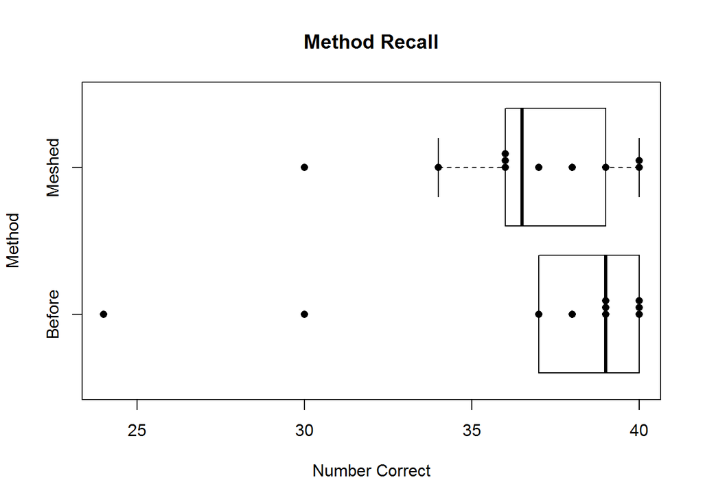

This graphic is a representation of the two different methods, “Before” and “Meshed”. Through the graphic we might be able to see that the “Before” method is a little more productive. The graphic represents the data and shows a left skew on the “Before” data and suggests that this method is more effective. In order to see if this is true, we must run the Rank-Sum test in order to see if the results are significant.

Wilcoxon rank sum test with continuity correction: `correct` by `condition`

| Test statistic | P value | Alternative hypothesis |
| --- | --- | --- |
| 62 | 0.378 | two.sided |

The Wilcoxon Rank-Sum test states that the test statistic is 62 and that the p-value is 0.378. Based on the graphic, we may think that the “Before” method is more effective, but because the level of significance is 0.05 and the p-value of our test is 0.378, we have to make a different statement.

#### Interpretation

With the null hypothesis being that the two methods of “Before” and “Meshed” are equally effective and the alternative hypothesis being that they are not equal, we can now make an inference on the data. With our level of significance being that of 0.05 and our p-value of 0.378 we are unable to state that the null hypothesis is incorrect. So, to answer the question of which test is more effective, we have to say that based on the Rank-Sum test I just performed, there is no difference in the effectiveness of the tests, or in other words we fail to reject the null.

In other situations I would like to see a repeat of this data. I think that by increasing the sample size we would be able to see more accurate results. I feel that by limiting the sample size to ten per method, we limit the results of our test and are unable to come up with the truth.